# finaltutorial

Analyzing Video Game sales

by Changlin Jiang

**1. Introduction**

1.2 Library Used

1.3 Data Description  
This dataset contains a list of video games with sales greater than 100,000 copies. It was generated by a scrape of vgchartz.com

- Rank - Ranking of overall sales
- Name - The games name
- Platform - Platform of the games release (i.e. PC,PS4, etc.)
- Year - Year of the game's release
- Genre - Genre of the game
- Publisher - Publisher of the game
- NA_Sales - Sales in North America (in millions)
- EU_Sales - Sales in Europe (in millions)
- JP_Sales - Sales in Japan (in millions)
- Other_Sales - Sales in the rest of the world (in millions)
- Global_Sales - Total worldwide sales.

```python
import pandas as pd
import datetime
import re
import numpy as np
from numpy import cos
import matplotlib.pyplot as plt
import seaborn as sns
from scipy import optimize
from scipy.optimize import curve_fit
import sklearn
from sklearn.linear_model import LinearRegression
from sklearn.preprocessing import RobustScaler
from sklearn.preprocessing import LabelEncoder
```

**2. Data Collection**  
2.1 Importing Data  
The dataset we used is retrieved from https://www.kaggle.com/datasets/gregorut/videogamesales?select=vgsales.csv

```python
vgdata = pd.read_csv("vgsales.csv",low_memory=False)
vgdata
```

|  | Rank | Name | Platform | Year | Genre | Publisher | NA_Sales | EU_Sales | JP_Sales | Other_Sales | Global_Sales |
| --- | --- | --- | --- | --- | --- | --- | --- | --- | --- | --- | --- |
| 0 | 1 | Wii Sports | Wii | 2006.0 | Sports | Nintendo | 41.49 | 29.02 | 3.77 | 8.46 | 82.74 |
| 1 | 2 | Super Mario Bros. | NES | 1985.0 | Platform | Nintendo | 29.08 | 3.58 | 6.81 | 0.77 | 40.24 |
| 2 | 3 | Mario Kart Wii | Wii | 2008.0 | Racing | Nintendo | 15.85 | 12.88 | 3.79 | 3.31 | 35.82 |
| 3 | 4 | Wii Sports Resort | Wii | 2009.0 | Sports | Nintendo | 15.75 | 11.01 | 3.28 | 2.96 | 33.00 |
| 4 | 5 | Pokemon Red/Pokemon Blue | GB | 1996.0 | Role-Playing | Nintendo | 11.27 | 8.89 | 10.22 | 1.00 | 31.37 |
| ... | ... | ... | ... | ... | ... | ... | ... | ... | ... | ... | ... |
| 16593 | 16596 | Woody Woodpecker in Crazy Castle 5 | GBA | 2002.0 | Platform | Kemco | 0.01 | 0.00 | 0.00 | 0.00 | 0.01 |
| 16594 | 16597 | Men in Black II: Alien Escape | GC | 2003.0 | Shooter | Infogrames | 0.01 | 0.00 | 0.00 | 0.00 | 0.01 |
| 16595 | 16598 | SCORE International Baja 1000: The Official Game | PS2 | 2008.0 | Racing | Activision | 0.00 | 0.00 | 0.00 | 0.00 | 0.01 |
| 16596 | 16599 | Know How 2 | DS | 2010.0 | Puzzle | 7G//AMES | 0.00 | 0.01 | 0.00 | 0.00 | 0.01 |
| 16597 | 16600 | Spirits & Spells | GBA | 2003.0 | Platform | Wanadoo | 0.01 | 0.00 | 0.00 | 0.00 | 0.01 |

16598 rows × 11 columns

```python
vgdata.info()
```

```
<class 'pandas.core.frame.DataFrame'>
RangeIndex: 16598 entries, 0 to 16597
Data columns (total 11 columns):
 #   Column        Non-Null Count  Dtype
---  ------        --------------  -----
 0   Rank          16598 non-null  int64
 1   Name          16598 non-null  object
 2   Platform      16598 non-null  object
 3   Year          16327 non-null  float64
 4   Genre         16598 non-null  object
 5   Publisher     16540 non-null  object
 6   NA_Sales      16598 non-null  float64
 7   EU_Sales      16598 non-null  float64
 8   JP_Sales      16598 non-null  float64
 9   Other_Sales   16598 non-null  float64
 10  Global_Sales  16598 non-null  float64
dtypes: float64(6), int64(1), object(4)
memory usage: 1.4+ MB
```

From the info, we see that there are some null values for the year column and the publisher column, so we remove those rows with null values from the dataset.

Also, there is one row with year 2020, which is wrong for this dataset from 1980 to 2017, we will try to find a real year for it.

2.2 Cleaning Data

```python
year_data = vgdata['Year']
print("Max Year Value: ", year_data.max())
max_entry = year_data.idxmax()
max_entry = vgdata.iloc[max_entry]
pd.DataFrame(max_entry).T
```

```
Max Year Value:  2020.0
```

|  | Rank | Name | Platform | Year | Genre | Publisher | NA_Sales | EU_Sales | JP_Sales | Other_Sales | Global_Sales |
| --- | --- | --- | --- | --- | --- | --- | --- | --- | --- | --- | --- |
| 5957 | 5959 | Imagine: Makeup Artist | DS | 2020.0 | Simulation | Ubisoft | 0.27 | 0.0 | 0.0 | 0.02 | 0.29 |

Makeup Artist game was launched in 16th April, 2009. Thus we will change 2020 to 2009

```python
vgdata['Year'] = vgdata['Year'].replace(2020.0, 2009.0)

game_nullyear = vgdata[vgdata['Year'].isnull()]["Name"].unique()
print("total number of unique games in that missing year is : ",len(game_nullyear))
print("Total Publisher missing for ", vgdata['Publisher'].isnull().sum(),' rows')
```

```
total number of unique games in that missing year is :  233
Total Publisher missing for  58  rows
```

```python
vgdata = vgdata.dropna()
vgdata.info()
vgdata.isnull().sum()
```

```
<class 'pandas.core.frame.DataFrame'>
Int64Index: 16291 entries, 0 to 16597
Data columns (total 11 columns):
 #   Column        Non-Null Count  Dtype
---  ------        --------------  -----
 0   Rank          16291 non-null  int64
 1   Name          16291 non-null  object
 2   Platform      16291 non-null  object
 3   Year          16291 non-null  float64
 4   Genre         16291 non-null  object
 5   Publisher     16291 non-null  object
 6   NA_Sales      16291 non-null  float64
 7   EU_Sales      16291 non-null  float64
 8   JP_Sales      16291 non-null  float64
 9   Other_Sales   16291 non-null  float64
 10  Global_Sales  16291 non-null  float64
dtypes: float64(6), int64(1), object(4)
memory usage: 1.5+ MB
```

```
Rank            0
Name            0
Platform        0
Year            0
Genre           0
Publisher       0
NA_Sales        0
EU_Sales        0
JP_Sales        0
Other_Sales     0
Global_Sales    0
dtype: int64
```

We have successfully imputed or removed null values.

**3. Data Visualization & Analysis**

3.1 Overall Statistics

```python
games = vgdata['Name'].unique()
publisher = vgdata['Publisher'].unique()
platforms = vgdata['Platform'].unique()
genres = vgdata['Genre'].unique()
print("total number of unique games: ",len(games))
print("total number of unique publisher: ",len(publisher))
print("total number of unique platforms: ",len(platforms))
print("total number of unique genres: ",len(genres))
```

```
total number of unique games:  11325
total number of unique publisher:  576
total number of unique platforms:  31
total number of unique genres:  12
```

3.2 Video Game Release by Year

```
(array([ 0,  1,  2,  3,  4,  5,  6,  7,  8,  9, 10, 11, 12, 13, 14, 15, 16,
        17, 18, 19, 20, 21, 22, 23, 24, 25, 26, 27, 28, 29, 30, 31, 32, 33,
        34, 35, 36, 37]),
 [Text(0, 0, '1980.0'),
```

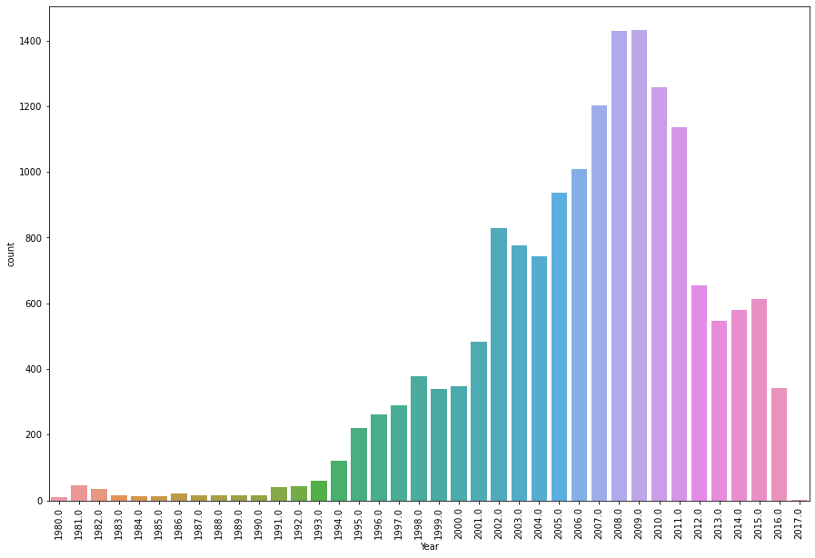

```python
# plt.figure(figsize=(15, 10))
# sns.countplot(x="Year", data=vgdata, order = vgdata.groupby(by=['Year'])['Name'].count().sort_values(ascending=False).index)
# plt.xticks(rotation=90)

plt.figure(figsize=(15, 10))
sns.countplot(x="Year", data=vgdata, order = vgdata.groupby(by=['Year'])['Name'].count().index)
plt.xticks(rotation=90)
```

From the plot, we can observe that 2009 was the year that released the most games from 1980 to 2017.

It seems 2007 to 2010 were the years that released the most games.

We can also observe a trend that the number of games released are increasing since 1980 and reached a peak at 2009, and then started to decrease overtime.

3.3 Video Game Release by Publisher

```
(array([ 0,  1,  2,  3,  4,  5,  6,  7,  8,  9, 10, 11, 12, 13, 14, 15, 16,
        17, 18, 19]),
 [Text(0, 0, 'Electronic Arts'),
```

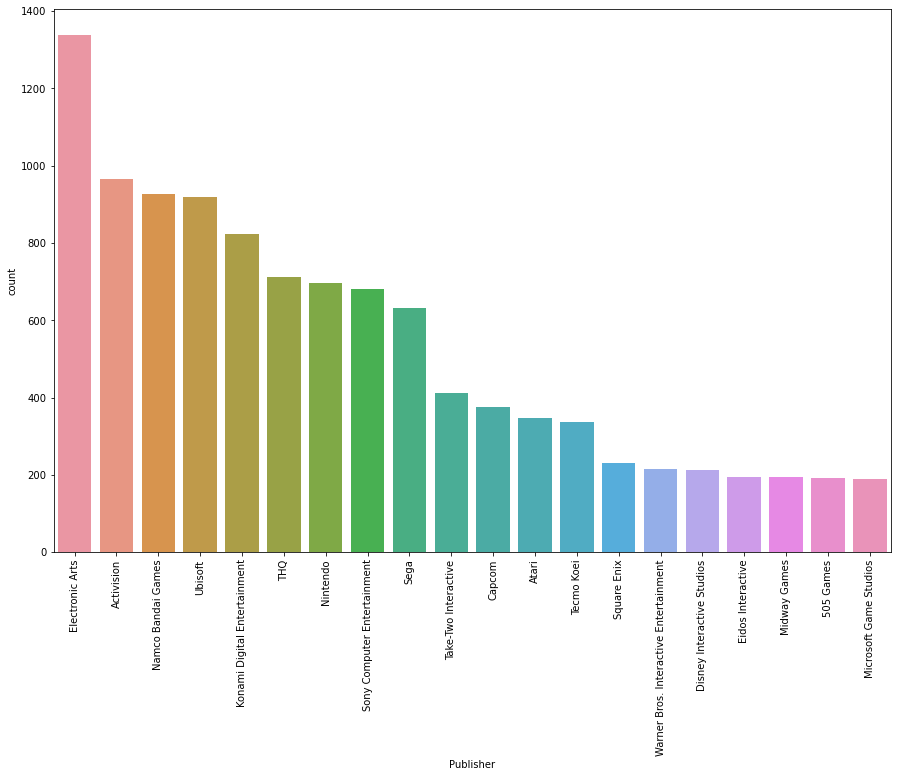

```python
top_publisher = vgdata.groupby(by=['Publisher'])['Year'].count().sort_values(ascending=False).head(20)
top_publisher = pd.DataFrame(top_publisher).reset_index()
plt.figure(figsize=(15, 10))
sns.countplot(x="Publisher", data=vgdata, order = vgdata.groupby(by=['Publisher'])['Year'].count().sort_values(ascending=False).iloc[:20].index)
plt.xticks(rotation=90)
```

3.4 Video Game Release by Platform

```
(array([ 0,  1,  2,  3,  4,  5,  6,  7,  8,  9, 10, 11, 12, 13, 14, 15, 16,
        17, 18, 19]),
 [Text(0, 0, 'DS'),
```

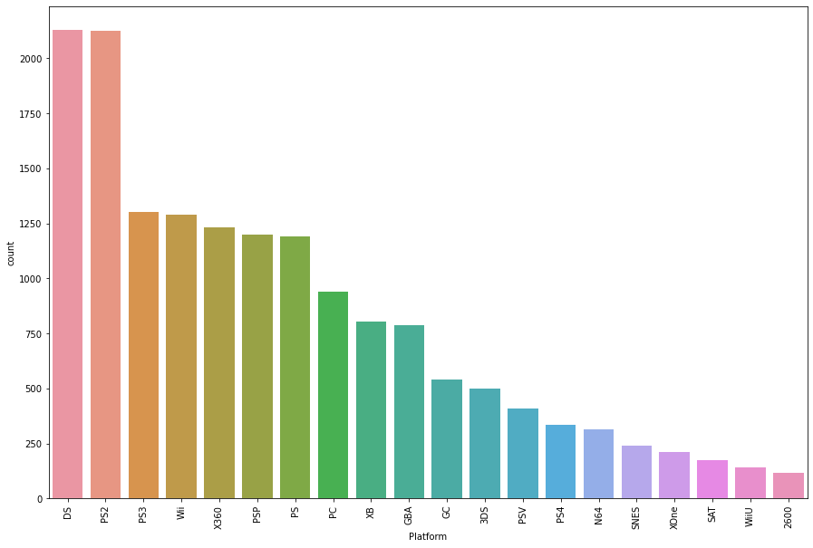

```python
top_platforms = vgdata.groupby(by=['Platform'])['Year'].count().sort_values(ascending=False).head(20)
top_platforms = pd.DataFrame(top_platforms).reset_index()
plt.figure(figsize=(15, 10))
sns.countplot(x="Platform", data=vgdata, order = vgdata.groupby(by=['Platform'])['Year'].count().sort_values(ascending=False).iloc[:20].index)
plt.xticks(rotation=90)
```

From this plot, we see that DS and PS2 have almost the same amount of video games released.

The most video games were released on the DS and PS2 platforms.